# Compare QNM and MSE output

Last Run 2024-09-23

**Author: M Fisher**

**Date written: 2023-12-20**

Last Updated: 2024-02-06 mcf

## Data

The QNM table is from script 02

```r
qnm <- read_csv(here('data','results',paste0('qnm0-5_hcra-e_pSims_',sim.date,'.csv'))) %>% clean_names()
```

The original MSE table is from the MSE software. If this isn’t the first time running the script, we can read in the R-formatted table. If it is, skip to below.

```r
mse_format <- read_csv(here('data','results','mse0-5_hcrb-d_species1-2_20240206.csv'))
```

First time running the script? We need to clean up a little and re-format the original MSE output table.

```r
mse <- read_csv(here('data','results','raw','mse_Table4_Species12_20240206.csv')) %>% clean_names()
mse_column_key <- data.frame(mse_column=c("total_c","cat_fl1","cat_fl2","ssb_ssb",
                                          "eff_fl1","eff_fl2"),
                             new_name=c("total_catch","fishery_1_catch","fishery_2_catch","spawning_biomass",
                                        "fishery_1_effort","fishery_2_effort"))

# clean up MSE output table
mse %<>% mutate(trial=str_replace(trial,'Results//Resu',''))
mse %<>% mutate(trial=str_replace(trial,'.out',''))
mse %<>% separate(col='trial',into=c('tmp1','tmp2','tmp3','tmp4'), sep='') %>%
  unite(tmp2,tmp4,col='code',sep="-") %>% dplyr::select(-tmp1,-tmp3)

mse_format <- mse %>% pivot_longer(cols=2:(dim(mse)[2]),names_to="variable",values_to="prob") %>%
  mutate(variable=ifelse(grepl("ssb",variable), paste0("ssb_",variable),variable)) %>%
  separate(variable,into=c("v1","v2","col_num"),sep="_") %>%
  filter(!is.na(col_num)) %>%    ## gets rid of column that just lists sim coutn (num_s1)
  mutate(model=ifelse(as.numeric(col_num) < 9, "MSE-Species1","MSE-Species2")) %>%
  unite(v1,v2, col="variable",sep="_") %>%
  left_join(mse_column_key,by=c("variable"="mse_column")) %>%
  dplyr::select(-col_num, -variable) %>% rename(variable_out=new_name)

## save
write_csv(mse_format, here('data','results','mse0-5_hcrb-d_species1-2_20240206.csv'))
```

## Prep data

### rerunning script

If this isn’t the first time running the script, read in the data frames from the next section. set code chunks to false.

```r
speciesALL_compare <- read_csv(here('data','results',paste0('mseVqnm_prob-psim_species1-2_allHCRallOM_',sim.date,'.csv'))) %>%
  filter(!is.na(model.y))  ## can't compare A. Status Quo for baseline, thorson effort

compareThorson <- read_csv(here('data','results',paste0('mse2Vqnm2_prob-psim_species1-2_ThorsonOMallHCR_',sim.date,'.csv')))
```

### first run of script

melt tables so that they can be combined

```r
qnm %<>% pivot_longer(cols=c(total_catch, fishery_1,fishery_2,spawning_biomass), names_to="variable_out", values_to="psims") %>%
  mutate(model="QNM") %>%
  mutate(variable_out=ifelse(variable_out=="fishery_1","fishery_1_catch",
                             ifelse(variable_out=="fishery_2","fishery_2_catch",variable_out)))

mse1 <- mse_format %>% filter(model=="MSE-Species1") %>%
  filter(variable_out %in% qnm$variable_out) %>%
  filter(code != "2-A")

mse2 <- mse_format %>% filter(model=="MSE-Species2") %>%
  filter(variable_out %in% qnm$variable_out) %>%
  filter(code != "2-A")
```

match mse species 1 / qnm

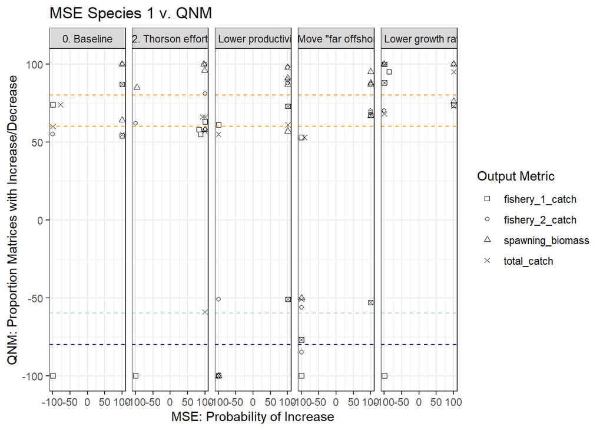

```r
species1_compare <- qnm %>% left_join(mse1, by=c("code","variable_out"))
ggplot(species1_compare, aes(x=prob,y=psims, pch=variable_out)) +
  geom_point() +
  geom_hline(aes(yintercept=60), col="orange", lty=2) +
  geom_hline(aes(yintercept=80), col="darkorange", lty=2) +
  geom_hline(aes(yintercept=-60), col="lightblue", lty=2) +
  geom_hline(aes(yintercept=-80), col="darkblue", lty=2) +
  facet_grid(cols=vars(operating_model)) +
  scale_shape_manual(values=c(0,1,2,4), name="Output Metric") +
  labs(x="MSE: Probability of Increase",y="QNM: Proportion Matrices with Increase/Decrease",
       title="MSE Species 1 v. QNM") +
  theme_bw()
```

match mse species 2 / qnm

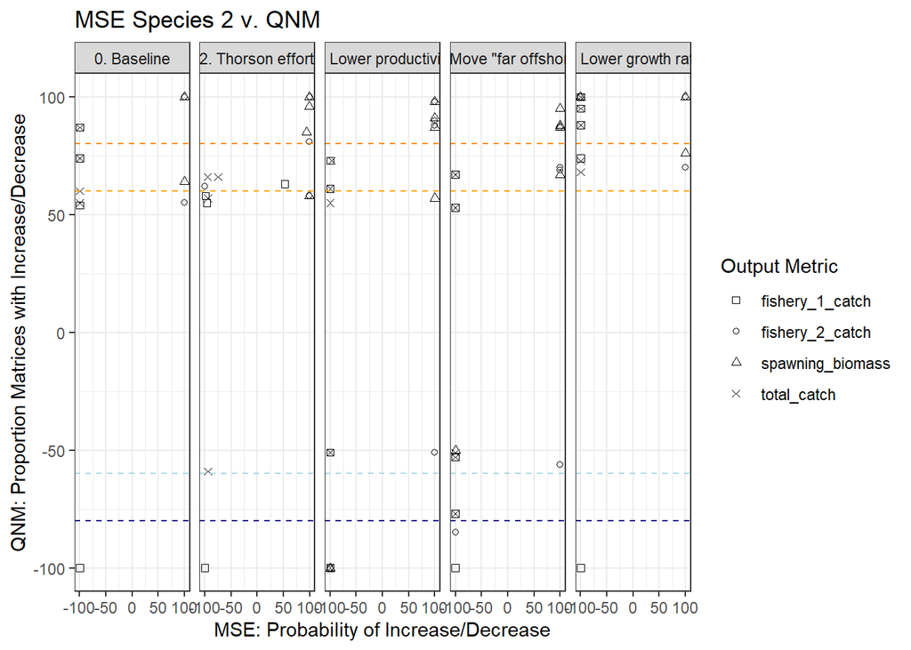

```r
species2_compare <- qnm %>% left_join(mse2, by=c("code","variable_out"))
ggplot(species2_compare, aes(x=prob,y=psims, pch=variable_out)) +
  geom_point() +
  geom_hline(aes(yintercept=60), col="orange", lty=2) +
  geom_hline(aes(yintercept=80), col="darkorange", lty=2) +
  geom_hline(aes(yintercept=-60), col="lightblue", lty=2) +
  geom_hline(aes(yintercept=-80), col="darkblue", lty=2) +
  facet_grid(cols=vars(operating_model)) +
  scale_shape_manual(values=c(0,1,2,4), name="Output Metric") +
  labs(x="MSE: Probability of Increase/Decrease",y="QNM: Proportion Matrices with Increase/Decrease",
       title="MSE Species 2 v. QNM") +
  theme_bw()
```

match multiple MSE versions of 2 Thorson Effort to QNM

```r
compareThorson <- qnm %>% filter(operating_model=="2. Thorson effort") %>%
  separate(code, into=c("om-code","ms-code"),sep="-",remove=FALSE) %>%
  dplyr::select(-"om-code") %>%
  left_join(mse_format %>% rename(mse_code=code) %>%
              separate(mse_code, into=c("om-code","ms-code"),sep="-",remove=FALSE) %>%
              filter(`om-code` %in% c("2","6","7")),
            by=c("ms-code","variable_out"))

compareThorson %<>% mutate(operating_model = ifelse(`om-code`=="6","Target 0.75x Biomass",
                                                    ifelse(`om-code`=="7","Target 1.25x Biomass","Target 1x Biomass (OG)")))
compareThorson$operating_model <- factor(compareThorson$operating_model, levels=c("Target 0.75x Biomass",
                                                                                  "Target 1x Biomass (OG)",
                                                                                  "Target 1.25x Biomass"))
```

save

```r
## all hcrs, oms
speciesALL_compare <- bind_rows(species1_compare, species2_compare)
write_csv(speciesALL_compare, here('data','results',paste0('mseVqnm_prob-psim_species1-2_allHCRallOM_',sim.date,'.csv')))

## thorson
write_csv(compareThorson, here('data','results',paste0('mse2Vqnm2_prob-psim_species1-2_ThorsonOMallHCR_',sim.date,'.csv')))
```

## Explore results: across OMs

I find it more helpful to look at tables, but I’ll also do some plotting below.

For each variable, look at cases where the direction of change was not a match. then break this down to determine whether the QNM was equivocal (aka, we wouldn’t want to make a decision off of the QNM response direction) or not (aka we would make a ‘wrong’ decision from the QNM response direction).

check: was any output 50/50?

```r
any(abs(speciesALL_compare$prob) == 50)
```

```
## [1] NA
```

```r
any(abs(speciesALL_compare$psims) == 50)
```

```
## [1] TRUE
```

ok, we need to account for 50/50 output (which shouldn’t be considered positive/negative) in the QNMs.

```r
summarise_mismatches <- speciesALL_compare %>%
  filter(code != "2-A") %>%    # no perturbation in 2-A so can't compare to MSE
  mutate(qnm_direction=ifelse(psims < 0 & abs(psims) != 50, "negative",
                              ifelse(psims > 0 & abs(psims) != 50, "positive","split")),
         mse_direction=ifelse(prob < 0, "negative","positive")) %>%
  mutate(qnm_equiv=ifelse(abs(psims) < 60, 1,0)) %>%
  mutate(directional_mismatch=ifelse(qnm_direction==mse_direction,0,
                                     ifelse(qnm_equiv==1,1,2))) %>%
  dplyr::select(code,model.y,variable_out,directional_mismatch) %>%
  pivot_wider(id_cols=c(code,model.y), names_from=variable_out,values_from=directional_mismatch)
```

mismatches summarized across OMs/HCRs for each variable:

```r
out1 <- summarise_mismatches %>%
  pivot_longer(cols=3:6, names_to="variable",values_to="mismatch_type") %>%
  group_by(model.y,variable,mismatch_type) %>%
  summarise(n=n()) %>%
  pivot_wider(names_from="mismatch_type",values_from="n", values_fill = 0) %>%
  adorn_percentages(denominator="row") %>%
  mutate(match=round(`0`,2),
         `mismatch - qnm equivocal`=round(`1`,2),
         `mismatch`=round(`2`,2)) %>% dplyr::select(-c(`0`,`1`,`2`))
kbl(out1)
```

| model.y | variable | match | mismatch - qnm equivocal | mismatch |
| --- | --- | --- | --- | --- |
| MSE-Species1 | fishery_1_catch | 0.65 | 0.13 | 0.22 |
| MSE-Species1 | fishery_2_catch | 0.83 | 0.04 | 0.13 |
| MSE-Species1 | spawning_biomass | 0.87 | 0.04 | 0.09 |
| MSE-Species1 | total_catch | 0.57 | 0.22 | 0.22 |
| MSE-Species2 | fishery_1_catch | 0.43 | 0.17 | 0.39 |
| MSE-Species2 | fishery_2_catch | 0.83 | 0.09 | 0.09 |
| MSE-Species2 | spawning_biomass | 0.91 | 0.04 | 0.04 |
| MSE-Species2 | total_catch | 0.26 | 0.17 | 0.57 |

Add a list column that saves exactly which OM-HCRs were true mismatches

```r
out1 %<>%
  left_join(
    summarise_mismatches %>%
      pivot_longer(cols=3:6, names_to="variable",values_to="mismatch_type") %>%
      group_by(model.y,variable,mismatch_type) %>%
      summarise(mismatch_codes=paste0(code,collapse=", ")) %>%
      filter(mismatch_type==2) %>%
      dplyr::select(model.y,variable,mismatch_codes)
  )
```

save to file

```r
# as csv
write_csv(out1, here('data','results',paste0('qnmVmse_mismatches_bySpbyVar',sim.date,'.csv')))

# as nice table
out1 %>%
  mutate(across(match:mismatch, as.character)) %>%
  pivot_longer(cols=c("match","mismatch - qnm equivocal","mismatch","mismatch_codes"), names_to="Qual v Quant", values_to="tmp_p") %>%
  pivot_wider(id_cols=c("model.y","Qual v Quant"), names_from="variable",values_from="tmp_p") %>%
  ungroup() %>% dplyr::select(`Qual v Quant`, total_catch, fishery_1_catch, fishery_2_catch,spawning_biomass) %>%
  rename(Total=total_catch, `Fishery 1`=fishery_1_catch, `Fishery 2`=fishery_2_catch, `Spawning Biomass`=spawning_biomass) %>%
    kbl() %>%
    kable_classic_2(full_width = F) %>%
      add_header_above(c(" ", "Catch" = 3, " " = 1)) %>%
  pack_rows("Species 1", 1, 4) %>%
  pack_rows("Species 2", 5, 8)
```

mismatches summarized across variables for OMs/HCRs:

```r
out2 <- summarise_mismatches %>%
  pivot_longer(cols=3:6, names_to="variable",values_to="mismatch_type") %>%
  group_by(model.y,code,mismatch_type) %>%
  summarise(n=n()) %>%
  pivot_wider(names_from="mismatch_type",values_from="n", values_fill = 0) %>%
  rename(match=`0`,
         `mismatch - qnm equivocal`=`1`,
         `mismatch`=`2`) %>%
  filter(`mismatch` > 0) %>%
  dplyr::select(model.y,code,mismatch) %>%
  separate(code, into=c("OM","HCR")) %>%
  pivot_wider(names_from="HCR",values_from="mismatch",values_fill=0) %>%
  dplyr::select(model.y,OM, A,B,C,D,E)
 out2 %>%
   ungroup() %>% dplyr::select(-model.y) %>%
   kbl() %>%
    kable_paper(full_width = T) %>%
   pack_rows("Species 1", 1, 4) %>%
  pack_rows("Species 2", 5, 9) %>%
   column_spec(1, bold=T)
```

| OM | A | B | C | D | E |
| --- | --- | --- | --- | --- | --- |
| **Species 1** |  |  |  |  |  |
| 0 | 0 | 1 | 0 | 0 | 2 |
| 2 | 0 | 0 | 2 | 0 | 0 |
| 3 | 0 | 0 | 0 | 0 | 1 |
| 5 | 4 | 1 | 1 | 1 | 2 |
| **Species 2** |  |  |  |  |  |
| 0 | 0 | 1 | 0 | 2 | 2 |
| 2 | 0 | 0 | 2 | 0 | 1 |
| 3 | 0 | 0 | 0 | 2 | 2 |
| 4 | 0 | 0 | 0 | 2 | 0 |
| 5 | 4 | 1 | 2 | 2 | 2 |

```r
  write_csv(out2, here('data','results',paste0('qnmVmse_mismatches_byOMbyHCR',sim.date,'.csv')))
```

plotting. aggregate across HCRs; look at OMs (x facet) by species (y facet)

```r
ggplot(speciesALL_compare, aes(x=prob,y=psims, pch=variable_out)) +
  geom_point() +
  geom_hline(aes(yintercept=60), col="orange", lty=2) +
  geom_hline(aes(yintercept=80), col="darkorange", lty=2) +
  geom_hline(aes(yintercept=-60), col="lightblue", lty=2) +
  geom_hline(aes(yintercept=-80), col="darkblue", lty=2) +
  facet_grid(cols=vars(operating_model), rows=vars(model.y)) +
  labs(x="MSE: Probability of Increase/Decrease",y="QNM: Proportion Simulations with Increase/Decrease",
       title="MSE v. QNM") +
  theme_bw() + theme(legend.title=element_blank())


png(here('data','results','qnmVmse_scatterplot_OM_by_species_2024-03-28.png'), width=2800,height=2000,res=300)
ggplot(speciesALL_compare, aes(x=prob,y=psims, pch=variable_out)) +
  geom_point() +
  geom_hline(aes(yintercept=60), col="orange", lty=2) +
  geom_hline(aes(yintercept=80), col="darkorange", lty=2) +
  geom_hline(aes(yintercept=-60), col="lightblue", lty=2) +
  geom_hline(aes(yintercept=-80), col="darkblue", lty=2) +
  facet_grid(cols=vars(operating_model), rows=vars(model.y)) +
  scale_shape_manual(values=c(0,1,2,4), name="Output Metric") +
  labs(x="MSE: Probability of Increase/Decrease",y="QNM: Proportion with Increase/Decrease",
       title="MSE v. QNM") +
  theme_bw() + theme(legend.title=element_blank())
dev.off()
```

for each species, look at OM (x facet) by hcr (y facet)

```r
png(here('data','results','qnmVmse_scatterplot_sp2_OM_by_HCR_2024-03-28.png'), width=2600,height=2000,res=300)
ggplot(species2_compare, aes(x=prob,y=psims, pch=variable_out)) +
  geom_point() +
  geom_hline(aes(yintercept=60), col="orange", lty=2) +
  geom_hline(aes(yintercept=80), col="darkorange", lty=2) +
  geom_hline(aes(yintercept=-60), col="lightblue", lty=2) +
  geom_hline(aes(yintercept=-80), col="darkblue", lty=2) +
  facet_grid(cols=vars(operating_model), rows=vars(management_strategy)) +
  scale_shape_manual(values=c(0,1,2,4), name="Output Metric") +
  labs(x="MSE: Probability of Increase",y="QNM: Proportion Simulations with Increase/Decrease",
       title="MSE Species 2 v. QNM") +
  theme_bw() + theme(strip.text.y=element_text(hjust=0))
dev.off()
#
# png(here('data','results','qnmVmse_scatterplot_sp1_OM_by_HCR_2024-03-28.png'), width=2800,height=2000,res=300)
# ggplot(species1_compare, aes(x=prob,y=psims, pch=variable_out)) +
#   geom_point() +
#   geom_hline(aes(yintercept=60), col="orange", lty=2) +
#   geom_hline(aes(yintercept=80), col="darkorange", lty=2) +
#   geom_hline(aes(yintercept=-60), col="lightblue", lty=2) +
#   geom_hline(aes(yintercept=-80), col="darkblue", lty=2) +
#   scale_shape_manual(values=c(0,1,2,4), name="Output Metric") +
#   facet_grid(cols=vars(operating_model), rows=vars(management_strategy)) +
#   labs(x="MSE: Probability of Increase",y="QNM: Proportion Simulations with Increase/Decrease",
#        title="MSE Species 1 v. QNM") +
#   theme_bw() + theme(strip.text.y=element_text(hjust=0))
# dev.off()
```

### Explore results: Thorson Effort

The Thorson effort quant MSE was run with different values of a parameter. Do quant MSE / QNM results match better at certain values of that parameter?

```r
thorson_mismatches <- compareThorson %>%
  filter(`ms-code` != "A") %>%
  mutate(qnm_direction=ifelse(psims < 0 & abs(psims) != 50, "negative",
                              ifelse(psims > 0 & abs(psims) != 50, "positive","split")),
         mse_direction=ifelse(prob < 0, "negative","positive")) %>%
  mutate(qnm_equiv=ifelse(abs(psims) < 60, 1,0)) %>%
  mutate(directional_mismatch=ifelse(qnm_direction==mse_direction,0,
                                     ifelse(qnm_equiv==1,1,2))) %>%
  dplyr::select(code,mse_code,operating_model,model.y, variable_out,directional_mismatch) %>%
  pivot_wider(id_cols=c(code,mse_code,operating_model,model.y), names_from=variable_out,values_from=directional_mismatch) %>%
  rename(species=model.y)

thorson_mismatches_summary <- thorson_mismatches %>%
  pivot_longer(cols=5:8, names_to="variable",values_to="mismatch_type") %>%
  group_by(species,operating_model,mismatch_type) %>%
  summarise(n=n()) %>%
  pivot_wider(names_from="mismatch_type",values_from="n", values_fill = 0) %>%
  rename(match=`0`,
         `mismatch - qnm equivocal`=`1`,
         `mismatch`=`2`) %>%
  mutate(sum = as.character(rowSums(across(where(is.numeric))))) %>%
  adorn_percentages(denominator="row")
thorson_mismatches_summary %>% kbl() %>%
    kable_paper()
```

| species | operating_model | match | mismatch - qnm equivocal | mismatch | sum |
| --- | --- | --- | --- | --- | --- |
| MSE-Species1 | Target 0.75x Biomass | 0.8125 | 0.0625 | 0.1250 | 16 |
| MSE-Species1 | Target 1x Biomass (OG) | 0.8125 | 0.0625 | 0.1250 | 16 |
| MSE-Species1 | Target 1.25x Biomass | 0.8125 | 0.0625 | 0.1250 | 16 |
| MSE-Species2 | Target 0.75x Biomass | 0.5625 | 0.1875 | 0.2500 | 16 |
| MSE-Species2 | Target 1x Biomass (OG) | 0.6250 | 0.1875 | 0.1875 | 16 |
| MSE-Species2 | Target 1.25x Biomass | 0.6875 | 0.1875 | 0.1250 | 16 |

Save tables.

```r
write_csv(thorson_mismatches_summary, here('data','results','qnm2Vmse2_mismatches_byTarget.csv'))
write_csv(thorson_mismatches, here('data','results','qnm2Vmse2_mismatches_byVar.csv'))
```

```r
png(here('data','results','qnmVmse_OM2ThorsonEffort_scatterplot_20240919.png'), width=3300,height=1600,res=300)
compareThorson %>%
  filter(`ms-code` != "A") %>%
  ggplot(aes(x=prob,y=psims, pch=variable_out)) +
  geom_point() +
  geom_hline(aes(yintercept=60), col="orange", lty=2) +
  geom_hline(aes(yintercept=80), col="darkorange", lty=2) +
  geom_hline(aes(yintercept=-60), col="lightblue", lty=2) +
  geom_hline(aes(yintercept=-80), col="darkblue", lty=2) +
  facet_grid(cols=vars(management_strategy), rows=vars(operating_model)) +
  scale_shape_manual(values=c(0,1,2,4), name="Output Metric") +
  labs(x="MSE: Probability of Increase/Decrease",y="QNM: Proportion with Increase/Decrease",
       title="MSE 2 v. QNM 2 (Thorson Effort)") +
  theme_bw() + theme(legend.title=element_blank())
dev.off()
```

QNM 2 x HCR C seems to perform better when target set to 1.25x biomass in the quant MSE, although the probability of increase for some of the variables is nearly 50%.

## Explore results: equivocal QNM

when the QNM was qualitatively *equivocal* ( <60% stable matrices had same response direction), did the direction generally agree with the quant MSE?

```r
speciesALL_equiv <- speciesALL_compare %>%
  filter((psims < 60 & psims > 0) | (psims > -60 & psims < 0))

speciesALL_equiv %<>% mutate(match_direction=ifelse(psims==50 | psims==-50,"split",
                                                    ifelse(psims < 0 & prob > 0, "negQNM-->posMSE",
                                                    ifelse(psims > 0 & prob < 0, "posQNM-->negMSE","match"))))
```

#### Species 1

“split” = the QNM output was 50/50

“match” = the QNM direction was the same as the MSE direction (+/+ or -/-)

“QNM–>MSE” = the QNM direction was different than the MSE direction. Directional difference in heading.

```
## match_direction
##           match negQNM-->posMSE posQNM-->negMSE           split
##      0.52380952      0.23809524      0.19047619      0.04761905
```

| variable_out | var_n | match | negQNM–>posMSE | posQNM–>negMSE | split |
| --- | --- | --- | --- | --- | --- |
| fishery_1_catch | 6 | 0.50 | 0.33 | 0.17 | 0.00 |
| fishery_2_catch | 4 | 0.75 | 0.00 | 0.25 | 0.00 |
| spawning_biomass | 3 | 0.67 | 0.00 | 0.00 | 0.33 |
| total_catch | 8 | 0.38 | 0.38 | 0.25 | 0.00 |

#### Species 2

“split” = the QNM output was 50/50

“match” = the QNM direction was the same as the MSE direction (+/+ or -/-)

“QNM–>MSE” = the QNM direction was different than the MSE direction. Directional difference in heading.

```
## match_direction
##           match negQNM-->posMSE posQNM-->negMSE           split
##      0.47619048      0.09523810      0.38095238      0.04761905
```

| variable_out | var_n | match | posQNM–>negMSE | negQNM–>posMSE | split |
| --- | --- | --- | --- | --- | --- |
| fishery_1_catch | 6 | 0.33 | 0.67 | 0.0 | 0.00 |
| fishery_2_catch | 4 | 0.50 | 0.00 | 0.5 | 0.00 |
| spawning_biomass | 3 | 0.67 | 0.00 | 0.0 | 0.33 |
| total_catch | 8 | 0.50 | 0.50 | 0.0 | 0.00 |

match_direction match negQNM–>posMSE posQNM–>negMSE split 0.40909091 0.09090909 0.40909091 0.09090909

## Explore Results: each operating model

for specific operating models, break out comparisons by management strategies and species

```r
png(here('results','QNM_v_MSE_0BaseModel_quantitative_scatterplot_2024-02-01.png'), width=3200,height=1500,res=300)
speciesALL_compare %>%
  filter(grepl('0',operating_model)) %>%
  ggplot(aes(x=prob,y=psims, pch=variable_out)) +
  geom_point() +
  geom_hline(aes(yintercept=60), col="orange", lty=2) +
  geom_hline(aes(yintercept=80), col="darkorange", lty=2) +
  geom_hline(aes(yintercept=-60), col="lightblue", lty=2) +
  geom_hline(aes(yintercept=-80), col="darkblue", lty=2) +
  facet_grid(cols=vars(management_strategy), rows=vars(model.y)) +
  scale_shape_manual(values=c(0,1,2,4), name="Output Metric") +
  labs(x="MSE: Probability of Increase/Decrease",y="QNM: Proportion Simulations with Increase/Decrease",
       title="MSE 0 v. QNM 0 (Base Model)") +
  theme_bw() + theme(legend.title=element_blank())
dev.off()


png(here('results','QNM_v_MSE_3LowerProductivity_quantitative_scatterplot_2024-02-01.png'), width=3200,height=1500,res=300)
speciesALL_compare %>%
  filter(grepl('3',operating_model)) %>%
  ggplot(aes(x=prob,y=psims, pch=variable_out)) +
  geom_point() +
  geom_hline(aes(yintercept=60), col="orange", lty=2) +
  geom_hline(aes(yintercept=80), col="darkorange", lty=2) +
  geom_hline(aes(yintercept=-60), col="lightblue", lty=2) +
  geom_hline(aes(yintercept=-80), col="darkblue", lty=2) +
  facet_grid(cols=vars(management_strategy), rows=vars(model.y)) +
  scale_shape_manual(values=c(0,1,2,4), name="Output Metric") +
  labs(x="MSE: Probability of Increase/Decrease",y="QNM: Proportion Simulations with Increase/Decrease",
       title="MSE 3 v. QNM 3 (Lower Productivity)") +
  theme_bw() + theme(legend.title=element_blank())
dev.off()
```